# BEATcc_MO39872_KN826_PoS

Anh Nguyen Duc

26 June, 2021

## 0.1 Supportive techinical resource

- https://arxiv.org/pdf/1711.08683.pdf
- (https://onlinelibrary.wiley.com/doi/full/10.1002/jrsm.1217

## 0.4 PoS for PFS

### 0.4.1 At the efficacy boundary from KN826 for PFS

```r
## PFS

# get the efficacy boundary for KN826
deg_PFS_826 <- getDesignGroupSequential(kMax = 2, alpha = 0.025, sided = 1, informationRates = c(182, 227)/227)

# HR PFS ITT = 0.73 is based on trial-errors to get 260 and 324 PFS events at 1st and 2nd IA (PFS FA)
sam_PFS_826 <- getSampleSizeSurvival(design = deg_PFS_826, hazardRatio = 0.73)
sam_PFS_826 %>% summary
```

Sample size calculation for a survival endpoint

Sequential analysis with a maximum of 2 looks (group sequential design). The sample size was calculated for a two-sample logrank test (one-sided), H0: hazard ratio = 1, H1: hazard ratio = 0.73, control pi(2) = 0.2, power 80%.

Stage 1 2 Information rate 80.2% 100% Efficacy boundary (z-value scale) 2.258 2.022 Overall power 0.6086 0.8000 Number of subjects 1859.5 1859.5 Cumulative number of events 260 324 Analysis time 15.4 18.0 Expected study duration 16.4 Cumulative alpha spent 0.0120 0.0250 One-sided local significance level 0.0120 0.0216 Efficacy boundary (t) 0.755 0.799

Legend: (t): approximate treatment effect scale

```r
meta_PFS <- bayesmeta(y      = c(log(0.92),              log(sam_PFS_826$criticalValuesEffectScale[2])),
                      sigma  = c(2/sqrt(664),            2/sqrt(227/.7) ),
                      labels = c('IMagyn050 Pimary CSR', "KN826"),
                      tau.prior = function(x){dhalfnormal(x,scale=1)})

meta_PFS %>% print
```

‘bayesmeta’ object.

2 estimates: IMagyn050 Pimary CSR, KN826

tau prior (proper): function(x){dhalfnormal(x,scale=1)} <bytecode: 0x0000000024aee5e8>

mu prior (improper): uniform(min=-Inf, max=Inf)

ML and MAP estimates: tau mu ML joint 0.00000000 -0.1298091 ML marginal 0.02882992 -0.1363272 MAP joint 0.00000000 -0.1298085 MAP marginal 0.02707165 -0.1362528

marginal posterior summary: tau mu mode 0.02707165 -0.1362528 median 0.27239752 -0.1424157 mean 0.42279458 -0.1477539 sd 0.43602561 0.4352428 95% lower 0.00000000 -1.0856647 95% upper 1.33207710 0.7783421

(quoted intervals are shortest credible intervals.)

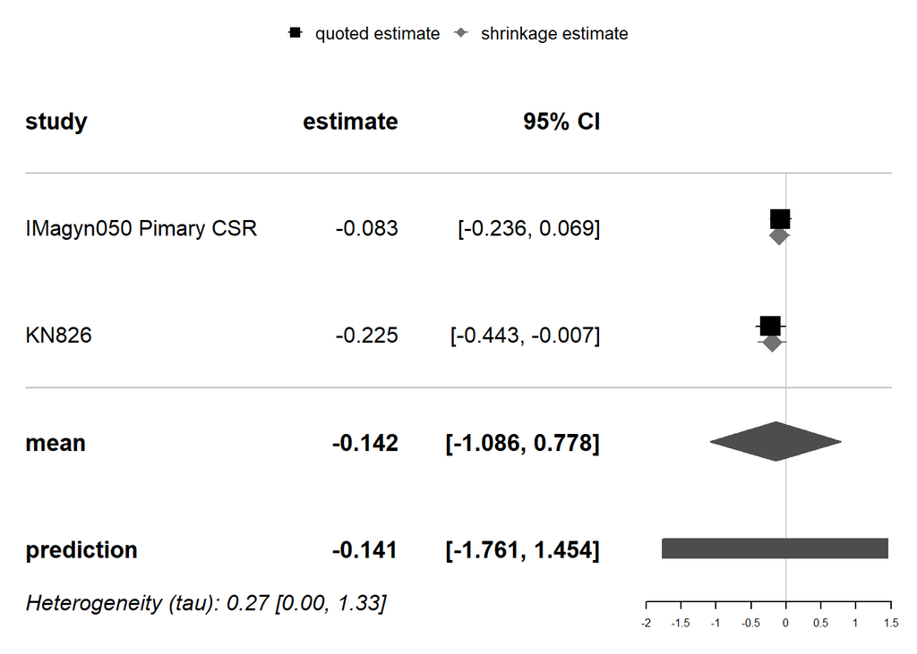

```r
forestplot(meta_PFS) %>% print
```

$data estimate lower upper IMagyn050 Pimary CSR -0.08338161 -0.2355043 0.068741099 KN826 -0.22487283 -0.4425506 -0.007195009 mean -0.14241572 -1.0856647 0.778342085 prediction -0.14085672 -1.7613600 1.454078693

$shrinkage estimate lower upper IMagyn050 Pimary CSR -0.09629755 -0.2428854 5.334388e-02 KN826 -0.19596297 -0.4102184 -1.078166e-05

$labeltext [,1] [,2] [,3]  
[1,] “study” “estimate” “95% CI”  
[2,] “IMagyn050 Pimary CSR” “-0.083” “[-0.236, 0.069]” [3,] “KN826” “-0.225” “[-0.443, -0.007]” [4,] “mean” “-0.142” “[-1.086, 0.778]” [5,] “prediction” “-0.141” “[-1.761, 1.454]”

$forestplot GRID.VP.1::forestplot_margins

```r
# This follows p27 of "Bayesian Random-Effects Meta-Analysis Using the bayesmeta R Package"
foo <- function(x) meta_PFS$dposterior(mu = x, predict = TRUE) * pnorm( (0.756%>%log - x) / (2/sqrt(280))  )

integrate(foo, lower=-Inf, upper=Inf)$value # Please note we need to use this for the effect estimate not the "true" study effect size
```

[1] 0.3345067

### 0.4.2 At several assumed observed PFS HR ITT from KN826

```r
# now we run through several assumed observed HR for PFS from KN826
# hrPFS_826 <- c(0.7986178, seq(.79, .7, -.005))

hrPFS_826 <- c(0.7986178, .775, .750, .725, .7, .675, .65)

PoS_PFS   <- Pos_PFS_no_050<- NULL

for (hr_pfs in hrPFS_826) {
  meta_pfs <- bayesmeta(y      = c(log(0.92),              log(hr_pfs)),
                        sigma  = c(2/sqrt(664),            2/sqrt(227/.7) ),
                        labels = c('IMagyn050 Pimary CSR', "KN826"),
                        tau.prior = function(x){dhalfnormal(x,scale=1)})

  foo <- function(x) meta_pfs$dposterior(mu = x, predict = TRUE) * pnorm( (0.756%>%log - x) / (2/sqrt(280))  )

  PoS_PFS        <- c(PoS_PFS, integrate(foo, lower=-Inf, upper=Inf)$value )
  Pos_PFS_no_050 <- c(Pos_PFS_no_050, pnorm( (0.756%>%log - hr_pfs%>%log) / (2/sqrt(280))  ) )
} # end of for (hr_pfs %in% hrPFS_826)

# plot(hrPFS_826, PoS_PFS, type='l', bty="7", xlab='Observed PFS HR in ITT in KN826', ylab='PoS for PFS in BEATcc')
rbind('hrPFS_826'=hrPFS_826, 'PoS_PFS_BEATcc'=PoS_PFS, 'PoS_PFS_BEATcc_no_050'=Pos_PFS_no_050) %>% kable(digits = 3, col.names = rep('.', PoS_PFS %>% length), row.names = T) %>% print
```

|  | . | . | . | . | . | . | . |
| --- | --- | --- | --- | --- | --- | --- | --- |
| hrPFS_826 | 0.799 | 0.775 | 0.750 | 0.725 | 0.700 | 0.675 | 0.650 |
| PoS_PFS_BEATcc | 0.335 | 0.356 | 0.379 | 0.403 | 0.427 | 0.449 | 0.469 |
| PoS_PFS_BEATcc_no_050 | 0.323 | 0.418 | 0.527 | 0.637 | 0.740 | 0.828 | 0.897 |

## 0.5 PoS for OS (IA)

### 0.5.1 At several assumed observed OS HR ITT from KN826

```r
# now we run through several assumed observed HR for PFS from KN826
# hrOS_826 <- c(0.82, seq(.79, .7, -.005))
hrOS_826 <- c(0.82, .8, .75, .7)

PoS_OS   <- Pos_OS_no_050 <- NULL

for (hr_OS in hrOS_826) {
  meta_OS <- bayesmeta(y      = c(log(0.96),              log(hr_OS)),
                       sigma  = c(2/sqrt(219),            2/sqrt(184/.7) ),
                       labels = c('IMagyn050 Pimary CSR', "KN826"),
                       tau.prior = function(x){dhalfnormal(x,scale=1)})

  foo <- function(x) meta_OS$dposterior(mu = x, predict = TRUE) * pnorm( (0.68%>%log - x) / (2/sqrt(197))  )

  PoS_OS        <- c(PoS_OS, integrate(foo, lower=-Inf, upper=Inf)$value )
  Pos_OS_no_050 <- c(Pos_OS_no_050, pnorm( (0.68%>%log - hr_OS%>%log) / (2/sqrt(197))  ) )
} # end of for (hr_OS %in% hrOS_826)

# plot(hrOS_826, PoS_OS, type='l', bty="7", xlab='Observed OS HR in ITT in KN826', ylab='PoS for OS in BEATcc')
rbind('hrOS_826'=hrOS_826, 'PoS_OS_BEATcc'=PoS_OS, 'PoS_OS_BEATcc_no_050'=Pos_OS_no_050) %>% kable(digits = 3, col.names = rep('.', PoS_OS %>% length), row.names = T) %>% print
```

|  | . | . | . | . |
| --- | --- | --- | --- | --- |
| hrOS_826 | 0.820 | 0.800 | 0.750 | 0.700 |
| PoS_OS_BEATcc | 0.248 | 0.261 | 0.299 | 0.341 |
| PoS_OS_BEATcc_no_050 | 0.094 | 0.127 | 0.246 | 0.419 |